# Mendelian Randomization Analysis

Dr. Shea Andrews

2018-10-12

## Instrumental Variables

**SNP Inclusion:** SNPS associated with at a p-value threshold of p < 5e-6 were included in this analysis.

**LD Clumping:** For standard two sample MR it is important to ensure that the instruments for the exposure are independent. LD clumping was performed in PLINK using the EUR samples from the 1000 Genomes Project to estimate LD between SNPs, and, amongst SNPs that have an LD above a given threshold, retain only the SNP with the lowest p-value. A clumping window of 250kb, r2 of 0.1 and significance level of 1 was used for the index and secondary SNPs.

**Proxy SNPs:** Where SNPs were not available in the outcome GWAS, the EUR thousand genomes was queried to identify potential proxy SNPs that are in linkage disequilibrium (r2 > 0.8) of the missing SNP.

| SNP | CHR | POS | Effect_allele | Non_Effect_allele | EAF | Beta | SE | P | r2 | N |
| --- | --- | --- | --- | --- | --- | --- | --- | --- | --- | --- |
| rs11675119 | 2 | 3476422 | A | C | 0.2699 | -0.2541 | 0.0488 | 1.931e-07 | 0.02544630 | 4914 |
| rs34487851 | 2 | 106642554 | A | G | 0.7314 | 0.2523 | 0.0550 | 4.459e-06 | 0.02501068 | 4914 |
| rs10166461 | 2 | 127859413 | A | G | 0.1733 | -0.2636 | 0.0570 | 3.816e-06 | 0.01990982 | 4914 |
| rs116351076 | 3 | 118356759 | T | C | 0.0358 | -0.6753 | 0.1461 | 3.826e-06 | 0.03148282 | 4914 |
| rs114498064 | 5 | 161442770 | T | C | 0.0131 | -1.5100 | 0.3137 | 1.480e-06 | 0.05895604 | 4914 |
| rs117530689 | 7 | 102030935 | A | C | 0.0178 | -4.0337 | 0.8423 | 1.678e-06 | 0.56892775 | 4914 |
| rs12595161 | 15 | 52922890 | A | G | 0.0511 | -0.4178 | 0.0914 | 4.883e-06 | 0.01692810 | 4914 |
| rs75680843 | 17 | 26640212 | T | C | 0.0721 | -0.3709 | 0.0809 | 4.590e-06 | 0.01840688 | 4914 |
| rs11654699 | 17 | 30903310 | T | C | 0.5243 | 0.2055 | 0.0449 | 4.628e-06 | 0.02106525 | 4914 |
| rs62117160 | 19 | 45232161 | A | G | 0.0227 | -0.9888 | 0.1949 | 3.891e-07 | 0.04338111 | 4914 |

[output cut: 3 more lines]

### Outcome: Alcohol Consumption

*Alcohol Consumption* (Clarke et al 2017): SNPs associated with alcohol consumption were selected from a GWAS of alcohol consumption (drinks per week adjusted for sex, age and weight) performed in 112,117 individuals from the UK Biobank [29]. Participants were of European ancestry, mean age was 59.6 and 52.7% of the cohort was female.

| SNP | CHR | POS | Effect_allele | Non_Effect_allele | EAF | Beta | SE | P | r2 | N |
| --- | --- | --- | --- | --- | --- | --- | --- | --- | --- | --- |
| rs11675119 | 2 | 3476422 | A | C | 0.24860 | -0.0018700 | 0.002990 | 0.5317 | 1.306428e-06 | 110915 |
| rs34487851 | 2 | 106642554 | G | A | 0.27310 | 0.0031240 | 0.003078 | 0.3103 | 3.874792e-06 | 104135 |
| rs10166461 | 2 | 127859413 | A | G | 0.18910 | 0.0003567 | 0.002986 | 0.9049 | 3.902070e-08 | 111235 |
| rs116351076 | 3 | 118356759 | T | C | 0.02886 | -0.0009437 | 0.003002 | 0.7532 | 4.992017e-08 | 110063 |
| rs114498064 | 5 | 161442770 | T | C | 0.01131 | 0.0011960 | 0.002988 | 0.6890 | 3.199006e-08 | 111094 |
| rs117530689 | 7 | 102030935 | A | C | 0.02202 | 0.0001090 | 0.003058 | 0.9716 | 5.117175e-10 | 105613 |
| rs12595161 | 15 | 52922890 | A | G | 0.04069 | -0.0012650 | 0.002974 | 0.6706 | 1.249274e-07 | 112176 |
| rs75680843 | 17 | 26640212 | T | C | 0.06405 | -0.0019570 | 0.002976 | 0.5109 | 4.591805e-07 | 112001 |
| rs11654699 | NA | NA | NA | NA | NA | NA | NA | NA | NA | NA |
| rs62117160 | 19 | 45232161 | A | G | 0.04604 | -0.0026190 | 0.002974 | 0.3785 | 6.025131e-07 | 112176 |

[output cut: 3 more lines]

**Table 3:** Proxy SNPs for Alcohol Consumption

| query_snp_rsid | rsID | ld.r2 | Dprime | ref.proxy | alt.proxy | CHR | POS | Effect_allele.proxy | Non_Effect_allele.proxy | EAF | Beta | SE | P | r2 | N | ref | alt | Effect_allele | Non_Effect_allele |
| --- | --- | --- | --- | --- | --- | --- | --- | --- | --- | --- | --- | --- | --- | --- | --- | --- | --- | --- | --- |
| rs11654699 | rs9904092 | 0.85 | 1.00 | TRUE | G | 17 | 30902615 | TRUE | G | 0.4489 | -0.0048320 | 0.002974 | 0.1042 | 1.155218e-05 | 112176 | C | T | C | T |
| rs157595 | rs439401 | 0.80 | 0.94 | TRUE | C | 19 | 45414451 | TRUE | C | 0.3609 | -0.0004135 | 0.002975 | 0.8894 | 7.887452e-08 | 112176 | A | G | A | G |
| rs6857 | NA | NA | NA | NA | NA | NA | NA | NA | NA | NA | NA | NA | NA | NA | NA | NA | NA | NA | NA |

## Data harmonization

| SNP | effect_allele.exposure | other_allele.exposure | effect_allele.outcome | other_allele.outcome | beta.exposure | beta.outcome | eaf.exposure | eaf.outcome | remove | palindromic | ambiguous | id.outcome | se.outcome | pval.outcome | outcome | mr_keep.outcome | pval_origin.outcome | se.exposure | pval.exposure | exposure | mr_keep.exposure | pval_origin.exposure | id.exposure | action | mr_keep | samplesize.outcome | mrpresso_RSSobs | mrpresso_pval | mrpresso_keep |
| --- | --- | --- | --- | --- | --- | --- | --- | --- | --- | --- | --- | --- | --- | --- | --- | --- | --- | --- | --- | --- | --- | --- | --- | --- | --- | --- | --- | --- | --- |
| rs10166461 | A | G | A | G | -0.2636 | 0.0003567 | 0.1733 | 0.18910 | FALSE | FALSE | FALSE | mCoylM | 0.002986 | 0.9049 | alcc | TRUE | reported | 0.0570 | 3.816e-06 | nft4 | TRUE | reported | 0UHDlM | 2 | TRUE | NA | NA | NA | TRUE |
| rs10402271 | T | G | T | G | -0.2747 | -0.0003091 | 0.6155 | 0.67830 | FALSE | FALSE | FALSE | mCoylM | 0.003003 | 0.9180 | alcc | TRUE | reported | 0.0462 | 2.675e-09 | nft4 | TRUE | reported | 0UHDlM | 2 | TRUE | NA | NA | NA | TRUE |
| rs114498064 | T | C | T | C | -1.5100 | 0.0011960 | 0.0131 | 0.01131 | FALSE | FALSE | FALSE | mCoylM | 0.002988 | 0.6890 | alcc | TRUE | reported | 0.3137 | 1.480e-06 | nft4 | TRUE | reported | 0UHDlM | 2 | TRUE | NA | NA | NA | TRUE |
| rs116351076 | T | C | T | C | -0.6753 | -0.0009437 | 0.0358 | 0.02886 | FALSE | FALSE | FALSE | mCoylM | 0.003002 | 0.7532 | alcc | TRUE | reported | 0.1461 | 3.826e-06 | nft4 | TRUE | reported | 0UHDlM | 2 | TRUE | NA | NA | NA | TRUE |
| rs11654699 | T | C | T | C | 0.2055 | 0.0048320 | 0.5243 | 0.55110 | FALSE | FALSE | FALSE | mCoylM | 0.002974 | 0.1042 | alcc | TRUE | reported | 0.0449 | 4.628e-06 | nft4 | TRUE | reported | 0UHDlM | 2 | TRUE | NA | NA | NA | TRUE |
| rs11675119 | A | C | A | C | -0.2541 | -0.0018700 | 0.2699 | 0.24860 | FALSE | FALSE | FALSE | mCoylM | 0.002990 | 0.5317 | alcc | TRUE | reported | 0.0488 | 1.931e-07 | nft4 | TRUE | reported | 0UHDlM | 2 | TRUE | NA | NA | NA | TRUE |
| rs117530689 | A | C | A | C | -4.0337 | 0.0001090 | 0.0178 | 0.02202 | FALSE | FALSE | FALSE | mCoylM | 0.003058 | 0.9716 | alcc | TRUE | reported | 0.8423 | 1.678e-06 | nft4 | TRUE | reported | 0UHDlM | 2 | TRUE | NA | NA | NA | TRUE |
| rs12595161 | A | G | A | G | -0.4178 | -0.0012650 | 0.0511 | 0.04069 | FALSE | FALSE | FALSE | mCoylM | 0.002974 | 0.6706 | alcc | TRUE | reported | 0.0914 | 4.883e-06 | nft4 | TRUE | reported | 0UHDlM | 2 | TRUE | NA | NA | NA | TRUE |
| rs157595 | A | G | A | G | -0.3872 | -0.0004135 | 0.3228 | 0.36090 | FALSE | FALSE | FALSE | mCoylM | 0.002975 | 0.8894 | alcc | TRUE | reported | 0.0551 | 2.041e-12 | nft4 | TRUE | reported | 0UHDlM | 2 | TRUE | NA | NA | NA | TRUE |
| rs34487851 | A | G | A | G | 0.2523 | -0.0031240 | 0.7314 | 0.72690 | FALSE | FALSE | FALSE | mCoylM | 0.003078 | 0.3103 | alcc | TRUE | reported | 0.0550 | 4.459e-06 | nft4 | TRUE | reported | 0UHDlM | 2 | TRUE | NA | NA | NA | TRUE |

[output cut: 2 more lines]

## MR Results

To obtain an overall estimate of causal effect, the SNP-exposure and SNP-outcome coefficients were combined in 1) a fixed-effects meta-analysis using an inverse-variance weighted approach (IVW); 2) a Weighted Median approach; 3) Weighted Mode approach and 4) Egger Regression.

[**IVW**](https://doi.org/10.1002/gepi.21758) is equivalent to a weighted regression of the SNP-outcome coefficients on the SNP-exposure coefficients with the intercept constrained to zero. This method assumes that all variants are valid instrumental variables based on the Mendelian randomization assumptions. The causal estimate of the IVW analysis expresses the causal increase in the outcome (or log odds of the outcome for a binary outcome) per unit change in the exposure. [**Weighted median MR**](https://doi.org/10.1002/gepi.21965) allows for 50% of the instrumental variables to be invalid. [**MR-Egger regression**](https://doi.org/10.1093/ije/dyw220) allows all the instrumental variables to be subject to direct effects (i.e. horizontal pleiotropy), with the intercept representing bias in the causal estimate due to pleiotropy and the slope representing the causal estimate. [**Weighted Mode**](https://doi.org/10.1093/ije/dyx102) gives consistent estimates as the sample size increases if a plurality (or weighted plurality) of the genetic variants are valid instruments.

| id.exposure | id.outcome | outcome | exposure | method | nsnp | b | se | pval |
| --- | --- | --- | --- | --- | --- | --- | --- | --- |
| 0UHDlM | mCoylM | alcc | nft4 | Inverse variance weighted (fixed effects) | 12 | 1.582808e-04 | 0.0006676249 | 0.8125943 |
| 0UHDlM | mCoylM | alcc | nft4 | Weighted median | 12 | -4.187382e-05 | 0.0007506379 | 0.9555136 |
| 0UHDlM | mCoylM | alcc | nft4 | Weighted mode | 12 | -5.091371e-05 | 0.0006985564 | 0.9432067 |
| 0UHDlM | mCoylM | alcc | nft4 | MR Egger | 12 | -3.598767e-04 | 0.0008437272 | 0.6787565 |

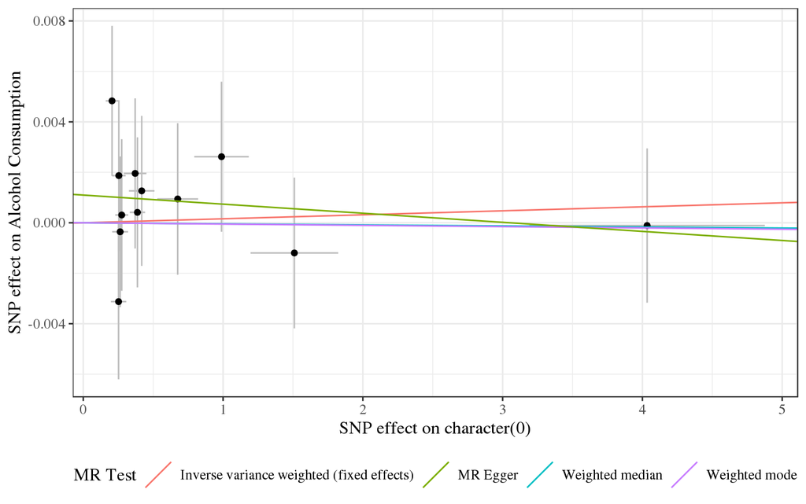

Fig. 1: Scatterplot of SNP effects for the association of the Exposure on the Outcome

## Pleiotropy

Figure 2 shows a funnel plot displaying the MR estimates of individual genetic variants against their precession. Aysmmetry in the funnel plot may arrise due to some genetic variants having unusally strong effects on the outcome, which is indicative of directional pleiotropy.

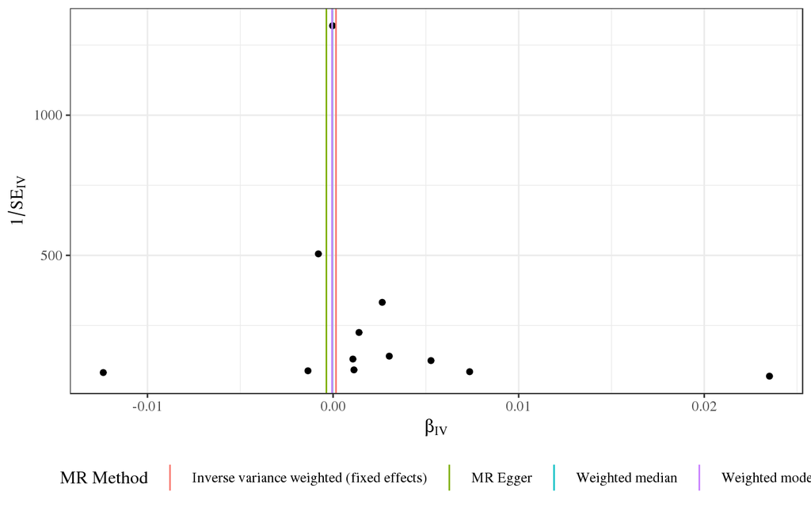

Fig. 2: Funnel plot of the MR causal estimates against their precession

A Cochrans Q heterogeneity test can be used to formaly assesse for the presence of heterogenity (Table 6).

**Table 6:** Heterogenity Tests

| id.exposure | id.outcome | outcome | exposure | method | Q | Q_df | Q_pval |
| --- | --- | --- | --- | --- | --- | --- | --- |
| 0UHDlM | mCoylM | alcc | nft4 | MR Egger | 4.689444 | 10 | 0.9109351 |
| 0UHDlM | mCoylM | alcc | nft4 | Inverse variance weighted | 5.698216 | 11 | 0.8927224 |

The intercept of the MR-Regression model captures the average pleitropic affect across all genetic variants (Table 7).

**Table 7:** MR Egger test for directional pleitropy

| id.exposure | id.outcome | outcome | exposure | egger_intercept | se | pval |
| --- | --- | --- | --- | --- | --- | --- |
| 0UHDlM | mCoylM | alcc | nft4 | 0.001098383 | 0.001093597 | 0.3388814 |

Pleiotropy was also assesed using Mendelian Randomization Pleiotropy RESidual Sum and Outlier [(MR-PRESSO)](https://doi.org/10.1038/s41588-018-0099-7), that allows for the evlation of evaluation of horizontal pleiotropy in a standared MR model (Table 8). MR-PRESSO performs a global test for detection of horizontal pleiotropy and correction of pleiotropy via outlier removal (Table 9).

**Table 8:** MR-PRESSO Global Test for pleitropy

| id.exposure | id.outcome | outcome | exposure | n_outliers | RSSobs | pval |
| --- | --- | --- | --- | --- | --- | --- |
| 0UHDlM | mCoylM | alcc | nft4 | 0 | 6.992642 | 0.892 |

**Table 9:** MR Estimates after MR-PRESSO outlier removal

| id.exposure | id.outcome | outcome | exposure | method | nsnp | b | se | pval |
| --- | --- | --- | --- | --- | --- | --- | --- | --- |
| 0UHDlM | mCoylM | alcc | nft4 | mrpresso | NA | NA | NA | NA |